# Report - Prelim. Analysis SuperLearner

Kevin W. McConeghy

Compiled: 2020-12-16

# Introduction

- Overall goal: accurately quantify morbidity and mortality attributable to influenza
- It is accepted diagnosed cases represent a underestimate of influenza impact
- Mathematical modeling is used to estimate the overt impact of disease
- The original methods for identifying attributable disease are dated
- We proposed testing the conventional methods against machine learning approaches including ensemble learning

# Objective

- We aim to estimate the forecasting accuracy of different model approaches compared to each other and an ensemble SuperLearner for estimating the number of deaths due to any cause in an influenza season

# Data

- Deaths, ILI activity, viral activity obtained from public CDC data.
- Include following seasons:  
  ** 2013/2014, 2014/2015, 2015/2016, 2016/2017, 2017/2018

## Prediction Target

- Weekly number of deaths due to any cause, summarized as:  
  ** Peak week  
  ** Peak height (number of deaths in worst week)  
  ** Cumulative deaths (Total number across entire season)

### Observed targets

| season | Peak Week | Peak Deaths | Cumulative Deaths |
| --- | --- | --- | --- |
| 2013-14 | 11 | 55,620 | 2,390,709 |
| 2014-15 | 11 | 61,737 | 2,506,101 |
| 2015-16 | 19 | 56,112 | 2,495,241 |
| 2016-17 | 11 | 60,980 | 2,583,468 |
| 2017-18 | 11 | 67,495 | 2,627,289 |

## Approach

- Generate set of datasets for a leave-one-out cross validation where ‘one’ is a influenza season.
- Apply a series of models to the datasets, generating predictions for the excluded dataset as the test case
- The SuperLearner will focus on minimizing the mean squared error, or L-2 squared error loss function  
  ** Learners: *** Cyclical regression with viral terms  
  *** Polynomial regression with ’’  
  *** Backwards AIC selection for linear model including fourier and polynomial terms, and lagged viral terms  
  *** Penalized regression: LASSO, Ridge and Elastic Net, lambda selected which minimizes AIC  
  *** Random forest: Default parameters, Node size 10, 5 variable selection at each node  
  *** GAM: Includes viral and week terms, each with splines. Penalized spline terms used

** Superlearner includes all of above, with predictions generated from each model added to a non-negative least squares model where the outcome was the observed number of events. The coefficients from the model were normalized and used as weights to generate new predictions combining the predictions of each model*model weight.

*re: weights for superlearner, these are generated from a NN-LS model with no intercept. It occurs to me, doesn’t that assume all observations are i.i.d., and therefore provides equal weights across a set of longutidinal values. So for example, if one learner performs better in early periods, but worse in later periods we effectively get a weight for average performance.*

*re: How are we doing model selection in GAM? I set up gamsel package which is basically penalized regression for gams.*

# Results

## Model Performance

Assessments from LOO-CV model:

### Peak week

| Model | 2013-14 | 2014-15 | 2015-16 | 2016-17 | 2017-18 |
| --- | --- | --- | --- | --- | --- |
| Observed | 11 | 11 | 19 | 11 | 11 |
| Cyclical LS | 9 | 9 | 19 | 15 | 14 |
| Polynomial LS | 9 | 9 | 19 | 15 | 14 |
| Natural splines LS | 10 | 9 | 19 | 15 | 14 |
| Backwards AIC LS | 11 | 7 | 23 | 17 | 17 |
| LASSO | 11 | 11 | 19 | 17 | 16 |
| Elastic Net | 11 | 11 | 19 | 17 | 16 |
| Ridge Regression | 11 | 11 | 19 | 17 | 16 |
| Random Forest (Dflt) | 11 | 10 | 18 | 17 | 11 |
| Random Forest (1) | 11 | 10 | 19 | 17 | 11 |
| GAM | 11 | 11 | 19 | 11 | 16 |
| Ensemble Superlearner | 11 | 9 | 19 | 15 | 11 |

## Peak cases

Percent difference between observed and predicted deaths at the height of season.

| Model | 2013-14 | 2014-15 | 2015-16 | 2016-17 | 2017-18 |
| --- | --- | --- | --- | --- | --- |
| Cyclical LS | 1.8% | -8.9% | 0.4% | 5.2% | -8.8% |
| Polynomial LS | 1.8% | -8.5% | 0.3% | 5.7% | -9.1% |
| Natural splines LS | 1.2% | -9.0% | 0.2% | 7.0% | -9.2% |
| Backwards AIC LS | 5.1% | -15.7% | 10.1% | 10.3% | -4.7% |
| LASSO | 2.4% | -9.3% | 4.4% | 5.6% | -6.3% |
| Elastic Net | 2.2% | -9.4% | 4.8% | 6.9% | -6.4% |
| Ridge Regression | 1.2% | -9.0% | 2.0% | 5.6% | -7.1% |
| Random Forest (Dflt) | 2.3% | -8.8% | 1.8% | 2.8% | -12.4% |
| Random Forest (1) | 2.1% | -8.8% | 1.1% | 1.4% | -13.1% |
| GAM | 3.3% | -4.0% | 3.0% | 5.5% | -4.8% |
| Ensemble Superlearner | 1.3% | -8.8% | 1.1% | 3.3% | -11.2% |

## Cumulative cases

| Model | 2013-14 | 2014-15 | 2015-16 | 2016-17 | 2017-18 |
| --- | --- | --- | --- | --- | --- |
| Cyclical LS | 4.6% | -2.3% | -0.0% | 1.4% | -2.8% |
| Polynomial LS | 4.6% | -2.4% | -0.1% | 1.6% | -2.9% |
| Natural splines LS | 4.6% | -2.3% | -0.0% | 2.0% | -2.9% |
| Backwards AIC LS | 3.7% | -6.3% | 1.7% | 3.6% | -2.1% |
| LASSO | 4.6% | -2.1% | 0.8% | 2.1% | -2.1% |
| Elastic Net | 4.6% | -2.3% | 0.9% | 2.5% | -2.1% |
| Ridge Regression | 4.4% | -2.1% | 0.4% | 2.1% | -2.3% |
| Random Forest (Dflt) | 4.8% | -3.5% | 1.0% | 0.4% | -3.0% |
| Random Forest (1) | 4.8% | -3.1% | 0.9% | 0.2% | -3.1% |
| GAM | 4.5% | -4.0% | 1.3% | 1.2% | -2.0% |
| Ensemble Superlearner | 4.7% | -2.8% | 0.5% | 0.9% | -2.8% |

## Cross-Validated Mean Squared Error

Model

Log (MSE)

Weight

Random Forest (1)

15.21764

0.46

Ensemble Superlearner

15.25348

Cyclical LS

15.25371

0.37

Random Forest (Dflt)

15.27586

0

Ridge Regression

15.29912

0.09

Polynomial LS

15.32491

0

Natural splines LS

15.33963

0

LASSO

15.34550

0

GAM

15.44578

0.07

Elastic Net

15.45814

0

Backwards AIC LS

16.47326

0

# Figure 1. Predicted vs. Observed data

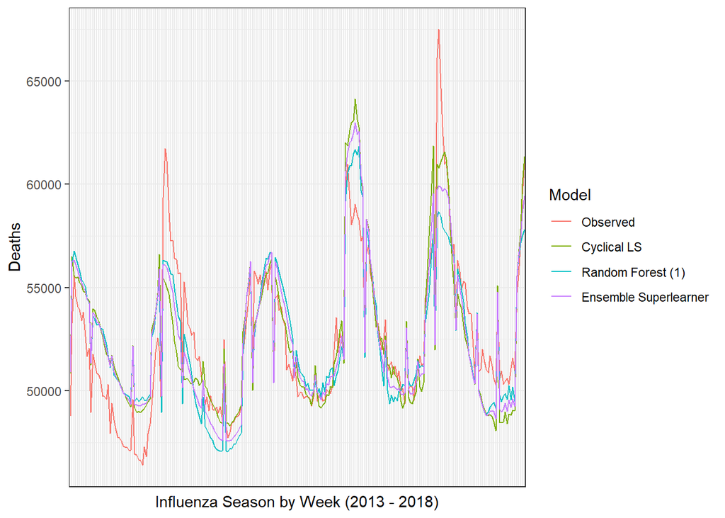

# Estimating Influenza Attributable Mortaltity